# Course guide

Bill Prisbrey

2025-12-12

**PURPOSE:** This report is a guide to recommended math courses for first time freshmen. It is based on the incoming qualifications of successful students (who achieve a minimum grade of B-) in the prior year.

*Report improvements*

- Add explanatory text
- Turn “year” into a parameter
- Turn plots into interactive “plotly” plots (allowing mouse-over and hover)
- Add number lines next to the table for ACT math test scores and high school GPA with the percentile markers
- Add descriptive information like the count or % of population per cluster or course
- Add sections:
  - Distance to course / top three closest courses (interactive)
  - Grade prediction per course / top three grades (interactive)
  - Explanation of grade prediction (SHAP values)

*Additional work*

- Investigate median unsuccessful student and compare distances
- Investigate whether higher HSGPA and ACTMATH than course median predicts lower grades (suggesting that students should be bumped up if they are >75th or >90th percentiles for a course) *DONE*
- Train a new predictive model that incorporates z-score distance. *DONE*

# Cluster placement

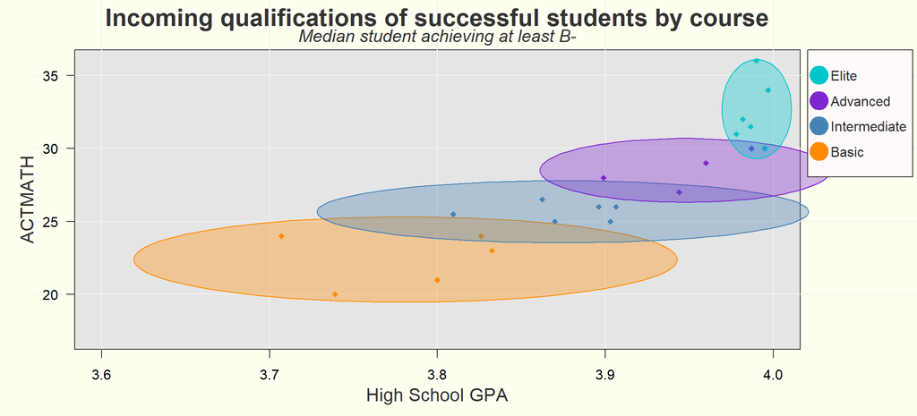

| Level | ACT Math Low | ACT Math High | High School GPA Low | High School GPA High |
| --- | --- | --- | --- | --- |
| Basic | 17 | 27 | 3.50 | 3.96 |
| Intermediate | 23 | 29 | 3.61 | 3.99 |
| Advanced | 25 | 32 | 3.73 | 4.00 |
| Elite | 29 | 36 | 3.93 | 4.00 |

# Cluster by cluster

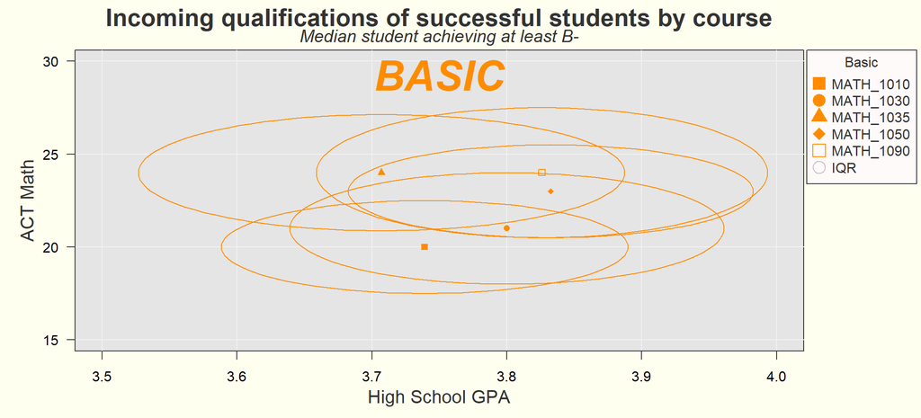

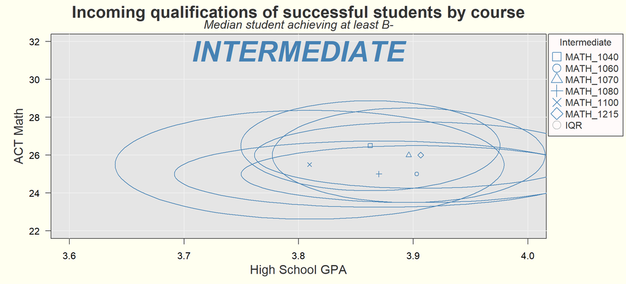

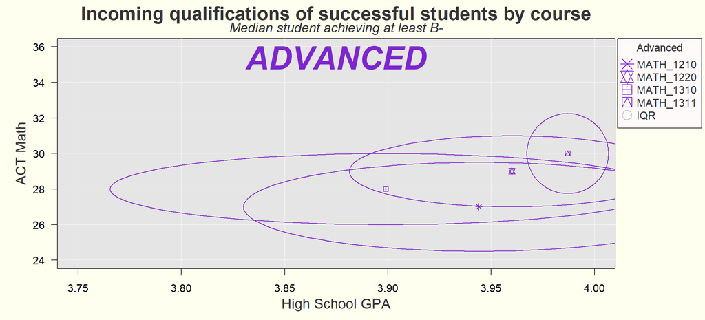

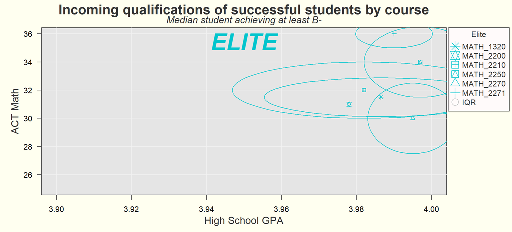

# Course detail

## Incoming ACT math test score percentiles of successful students by course

*where successful students achieved a grade of B-minus or better.*

Incoming ACT Math test score percentiles of students achieving B-minus or better by course

| course | 10th | 25th | 50th | 75th | 90th |
| --- | --- | --- | --- | --- | --- |
| MATH_1010 | 16.0 | 17.00 | 20.0 | 22.00 | 24.5 |
| MATH_1030 | 16.0 | 18.00 | 21.0 | 24.00 | 25.0 |
| MATH_1035 | 17.4 | 18.75 | 24.0 | 25.00 | 25.3 |
| MATH_1050 | 18.0 | 20.00 | 23.0 | 25.00 | 27.0 |
| MATH_1090 | 18.0 | 20.00 | 24.0 | 27.00 | 28.0 |
| MATH_1060 | 21.3 | 23.00 | 25.0 | 26.00 | 28.0 |
| MATH_1070 | 19.0 | 23.00 | 26.0 | 28.00 | 29.6 |
| MATH_1100 | 20.0 | 23.00 | 25.5 | 28.75 | 32.0 |
| MATH_1080 | 22.0 | 23.50 | 25.0 | 27.00 | 30.0 |
| MATH_1040 | 18.8 | 24.00 | 26.5 | 28.75 | 34.1 |
| MATH_1215 | 20.3 | 24.25 | 26.0 | 27.75 | 28.9 |
| MATH_1210 | 23.0 | 25.00 | 27.0 | 30.00 | 32.0 |
| MATH_1310 | 24.0 | 26.00 | 28.0 | 30.00 | 33.0 |
| MATH_1220 | 26.0 | 27.00 | 29.0 | 31.00 | 34.0 |
| MATH_1311 | 25.4 | 27.00 | 30.0 | 31.50 | 32.0 |
| MATH_2270 | 28.3 | 29.00 | 30.0 | 34.00 | 34.7 |
| MATH_2210 | 27.5 | 30.00 | 32.0 | 34.00 | 35.0 |
| MATH_1320 | 28.7 | 30.25 | 31.5 | 33.00 | 34.0 |
| MATH_2200 | 31.0 | 31.00 | 31.0 | 31.00 | 31.0 |
| MATH_2250 | 26.8 | 31.00 | 34.0 | 36.00 | 36.0 |
| MATH_2271 | 30.4 | 34.00 | 36.0 | 36.00 | 36.0 |

## Incoming high school GPA percentiles of successful students by course

*where successful students achieved a grade of B-minus or better.*

Incoming high school GPA percentiles of students achieving B-minus or better by course

| course | 10th | 25th | 50th | 75th | 90th |
| --- | --- | --- | --- | --- | --- |
| MATH_1035 | 3.32 | 3.50 | 3.71 | 3.86 | 3.92 |
| MATH_1010 | 3.39 | 3.59 | 3.74 | 3.90 | 3.96 |
| MATH_1090 | 3.45 | 3.60 | 3.83 | 3.94 | 3.99 |
| MATH_1080 | 3.44 | 3.61 | 3.87 | 3.97 | 3.99 |
| MATH_1030 | 3.38 | 3.63 | 3.80 | 3.95 | 4.00 |
| MATH_1100 | 3.54 | 3.64 | 3.81 | 3.98 | 4.00 |
| MATH_1050 | 3.45 | 3.66 | 3.83 | 3.96 | 4.00 |
| MATH_1215 | 3.37 | 3.67 | 3.91 | 3.97 | 4.00 |
| MATH_1060 | 3.53 | 3.68 | 3.90 | 3.99 | 4.00 |
| MATH_1310 | 3.58 | 3.73 | 3.90 | 3.99 | 4.00 |
| MATH_1040 | 3.53 | 3.74 | 3.86 | 3.96 | 3.99 |
| MATH_1070 | 3.54 | 3.75 | 3.90 | 3.98 | 4.00 |
| MATH_1210 | 3.50 | 3.77 | 3.94 | 4.00 | 4.00 |
| MATH_1220 | 3.71 | 3.84 | 3.96 | 4.00 | 4.00 |
| MATH_2210 | 3.83 | 3.93 | 3.98 | 4.00 | 4.00 |
| MATH_1320 | 3.64 | 3.94 | 3.99 | 4.00 | 4.00 |
| MATH_1311 | 3.94 | 3.96 | 3.99 | 4.00 | 4.00 |
| MATH_2250 | 3.77 | 3.97 | 4.00 | 4.00 | 4.00 |
| MATH_2270 | 3.95 | 3.98 | 4.00 | 4.00 | 4.00 |
| MATH_2200 | 3.98 | 3.98 | 3.98 | 3.98 | 3.98 |
| MATH_2271 | 3.98 | 3.98 | 3.99 | 4.00 | 4.00 |

# Predictive Modeling

A predictive model for math grades is developed that uses information readily available upon enrollment.

The model primarily relies on the student’s high school GPA and ACT math test scores. It also uses the difference between the student’s qualifications and the prior year’s median successful student’s qualifications.

Generally, the model finds that math grades improve with higher ACT math test scores and high school GPA, and declines with distance to the prior year’s successful student.

## *Identify high and low risk groups:*

A predictive model can identify a group of students with a high rate of failure. Roughly one-third of these “high risk” students will fail (achieving a grade less than 1.7, or D+ or less.) This compares to the “low risk” students, with only a 5% failure rate (one in twenty.)

## *Compare predicted grades across courses:*

The model can produce predicted grades per course per student and can be used to compare courses and select courses where the expected grade is higher.

These predicted grades align to the actual grades with an r-squared value of 0.26, meaning that the incoming qualifications account for only about a quarter of the variation in grade performance. Qualities and factors that presumably have an impact but are not included in the model are individual motivation, student-teacher alignment, course schedule, difficulty and number of concurrent courses, and other individual circumstances.

The predicted grades also have a mean absolute error of 0.81, putting almost an entire grade point margin of error onto any individual prediction. This margin of error suggests that incoming qualifications of high school GPA and ACT math test scores are not deterministic and that high values in either category do not guarantee success.

It also suggests that the predictive model should only be used as a loose guideline. Examples of individual recommendations accompany this guide.

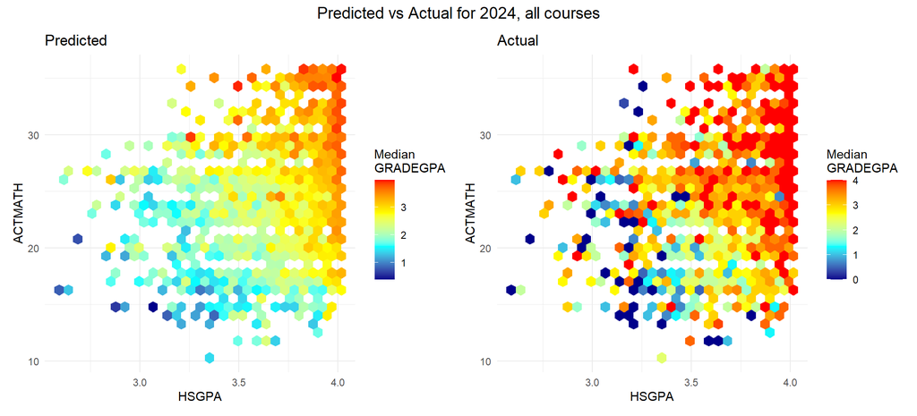

Performance by risk group

|  | Fail (<1.7) | Pass (≥1.7) |
| --- | --- | --- |
| High risk | 170 (8.8%) | 417 (21.6%) |
| Low risk | 59 (3%) | 1289 (66.6%) |